# Figure 3c

Monitoring growth of miR34a asRNA overexpressings cells under conditions of starvation

Jason T. Serviss

31/01/2017

```r
projectUrl <- "https://github.com/GranderLab/miR34a_asRNA_project/raw/master/inst/"
dataUrl <- "https://github.com/GranderLab/miR34a_asRNA_project/raw/master/data"
```

#### *Introduction*

As p53 is a well-known regulator of senescence, growth, and apoptosis and has been shown to specifically important under conditions of cellular stress, such as starvation. Therefore, we investigated whether overexpression of miR34a AS affects growth rate under normal and starvation conditions by measuring changes in confluency over time.

#### *Methods*

*Cell culture and confluency quantification*

10^4 PC3 cells, either miR34a asRNA overexpressing or WT, were seeded in 96 well plates. After attachment (3-4h) media was replaced with either RPMI (Gibco, life technology) (supplemented with 2mM L-glutamine, 50ug/ml Penicillin-Streptomycin and 10% Fetal Calf Serum) or HBSS. Cells were incubated in Spark Multimode Microplate reader for 48 hours at 37°C with 5% CO2 in a humidity chamber. Confluency was measured every hour.

*Analysis*

Three technical triplicates were included in each experiment and these were independantly normalized for each condition to the 0 time point afterwhich the mean was calculated. The 95% confidence interval was then calculated based on the three independant experiments which were preformed.

#### *Results*

```r
url <- "figure3c_stableLineGrowthStarvation.rds"
data <- read_rds(gzcon(url(file.path(dataUrl, url))))

#normalize to first time point for control (Mock)
.normFun <- function(
  data,
  Confluency,
  Treatment,
  Biological.Replicate,
  Technical.Replicate,
  Cell.line
){
  bool1 <- data$Treatment == Treatment
  bool2 <- data$`Biological Replicate` == Biological.Replicate
  bool3 <- data$`Technical Replicate` == Technical.Replicate
  bool4 <- data$Time == 0
  bool5 <- data$`Cell line` == Cell.line
  bool <- bool1 & bool2 & bool3 & bool4 & bool5
  Confluency / pull(data, Confluency)[bool]
}

data <- data %>%
  group_by(Treatment, `Biological Replicate`, `Technical Replicate`, Time, `Cell line`) %>%
  mutate(
    normConfluency = .normFun(
      data,
      Confluency,
      Treatment,
      `Biological Replicate`,
      `Technical Replicate`,
      `Cell line`
    )
  ) %>%
  ungroup()

#calculate mean for each technical replicate
data <- data %>%
  group_by(Treatment, `Biological Replicate`, Time, `Cell line`) %>%
  summarize(
    techMean = mean(normConfluency)
  ) %>%
  ungroup()

#calculate stats
stats <- data %>%
  filter(Time != 0) %>%
  group_by(`Cell line`, Treatment, Time) %>%
  summarize(
    min = min(techMean),
    max = max(techMean),
    mean = mean(techMean),
    median = median(techMean),
    CI95l = t.test(techMean)$conf.int[1],
    CI95h = t.test(techMean)$conf.int[2]
  )
```

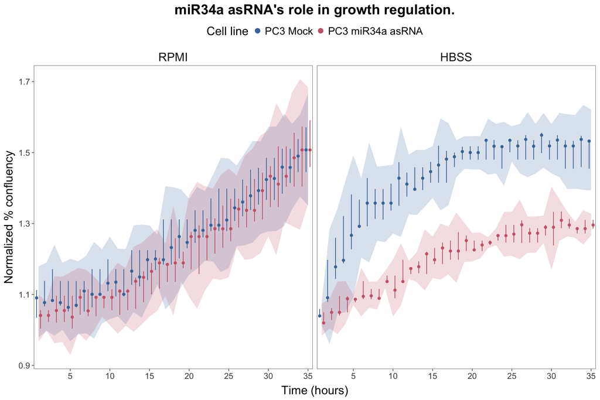

```r
p <- ggplot(data = NULL) +
  geom_ribbon(
    data = stats,
    aes(
      x = Time,
      ymin = CI95l,
      ymax = CI95h,
      group = `Cell line`,
      fill = `Cell line`
    ),
    alpha = 0.2,
    show.legend = FALSE
  ) +
  facet_grid(. ~ Treatment) +
  scale_x_discrete(breaks = seq(0, 35, 5)) +
  labs(
    x = "Time (hours)",
    y = "Normalized % confluency",
    title = "miR34a asRNA's role in growth regulation."
  ) +
  guides(
    colour = guide_legend(title = "Cell line", override.aes = list(size = 3))
  )

markdown <- p +
  geom_linerange(
    data = stats,
    aes(
      x = Time,
      colour = `Cell line`,
      ymin = min,
      ymax = max
    ),
    position = position_dodge(width = 1),
    show.legend = FALSE
  ) +
  geom_point(
    data = stats,
    aes(
      x = Time,
      y = median,
      group = `Cell line`,
      colour = `Cell line`
    ),
    position = position_dodge(width = 1),
    show.legend = TRUE
  ) +
  guides(
    colour = guide_legend(
      title = "Cell line",
      override.aes = list(size = 3)
    )
  )

plotRmarkdown(markdown)
```

```r
pdf <- p +
  geom_linerange(
    data = stats,
    aes(
      x = Time,
      colour = `Cell line`,
      ymin = min,
      ymax = max
    ),
    position = position_dodge(width = 1),
    lwd = 0.1,
    show.legend = FALSE
  ) +
  geom_point(
    data = stats,
    aes(
      x = Time,
      y = median,
      group = `Cell line`,
      colour = `Cell line`
    ),
    size = 0.25,
    position = position_dodge(width = 1),
    show.legend = TRUE
  ) +
  guides(
    colour = guide_legend(
      title = "Cell line",
      override.aes = list(size = 2)
    )
  )

figure <- plotPDF(pdf)
path <- "~/GitHub/miR34a_asRNA_project/inst/figure3c_stableLineGrowthStarvation/figure3c_stableLineGrowthStarvation.pdf"

ggsave(
  plot = figure,
  filename = path,
  device = cairo_pdf,
  height = 60,
  width = 83,
  units = "mm"
)
```

The effects of miR34a asRNA overexpression on growth in normal and starvation conditions in the PC3 prostate cancer cell line. The points represent the median values obtained from each independant experiment (n = 3) whereas, the shadow represents 95% confidence interval, and the vertical line represents the minimum and maximum values from the independant experiments.

#### *Conclusions*

miR34a asRNA overexpression causes a minor decrease in cell growth under normal conditions (RPMI) although under conditions of cellular stress through starvation, this effect is increased dramatically.